# Lab 4 for Intorduction to computational finance

# task 1 Simulate data from a MA(1) model

- Simulate 250 observations from the above MA(1) model with θ=0.5 and the constant 0.05. Assign the result to ma1_sim.

```r
set.seed(123);
# Simulate 250 observations from the described MA(1) model
ma1_sim <- arima.sim(model=list(ma=0.5), n=250, mean=0, sd=0.1) + 0.05
```

# task 2 Plot the data from the simulated MA(1) model

- Make a line plot of the observations in ma1_sim with the title “MA(1) Process: mu=0.05, theta=0.5”. Label the x-axis with “time” and the y-axis with “y(t)”. A line plot can be specified by setting type=“l” of the plot() function.
- Add a horizontal line at zero.

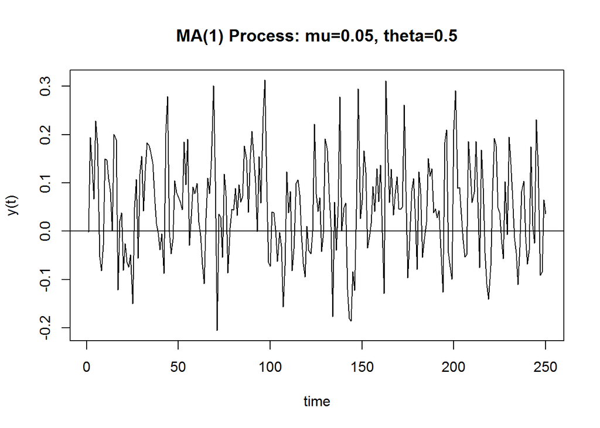

```r
# A line plot of the simulated observations
plot(ma1_sim, type = "l", main = "MA(1) Process: mu=0.05, theta=0.5", xlab  = "time", ylab = "y(t)")
abline(h = 0)
```

# task 3 Plotting the theoretical and the sample ACF

- Use the ARMAacf function to calculate the theoretical autocorrelations up to lag 10. Assign the result to acf_ma1_model.
- Construct the plot of the sample autocorrelations up to lag 10 by using the acf() function. Set the title of the plot to “Sample ACF”.

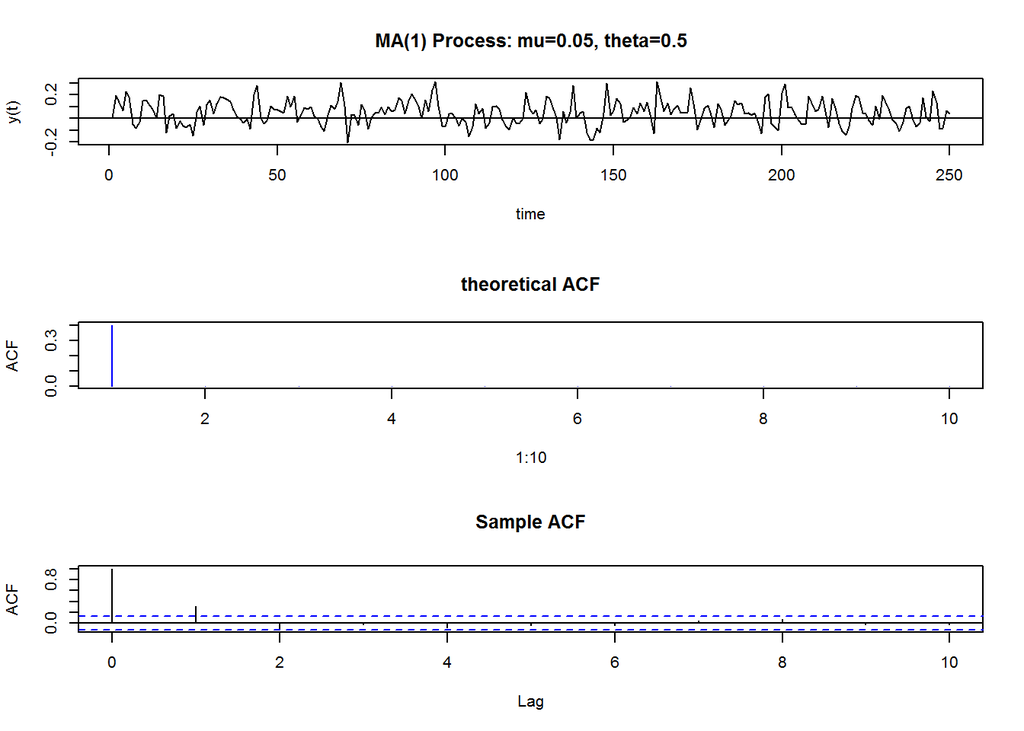

```r
# Generate the theoretical ACF with upto lag 10
acf_ma1_model <- ARMAacf(ma = 0.5, lag.max = 10)
# Split plotting window in three rows
par(mfrow=c(3,1))
# First plot: The simulated observations
plot(ma1_sim, type="l",main="MA(1) Process: mu=0.05, theta=0.5",xlab="time",ylab="y(t)")
abline(h=0)
# Second plot: Theoretical ACF
plot(1:10, acf_ma1_model[2:11], type="h", col="blue",  ylab="ACF", main="theoretical ACF")
# Third plot: Sample ACF
# Assign to tmp the Sample ACF
tmp <- acf(ma1_sim, lag.max = 10, main = "Sample ACF")
```

```r
# Reset graphical window to only one graph
par(mfrow=c(1,1))
```

# task 4 A different MA(1) model

- Now assume that θ=0.9 instead of θ=0.5. Rewrite the code on the right such that it simulates data from the correct model and displays the three graphs correctly.

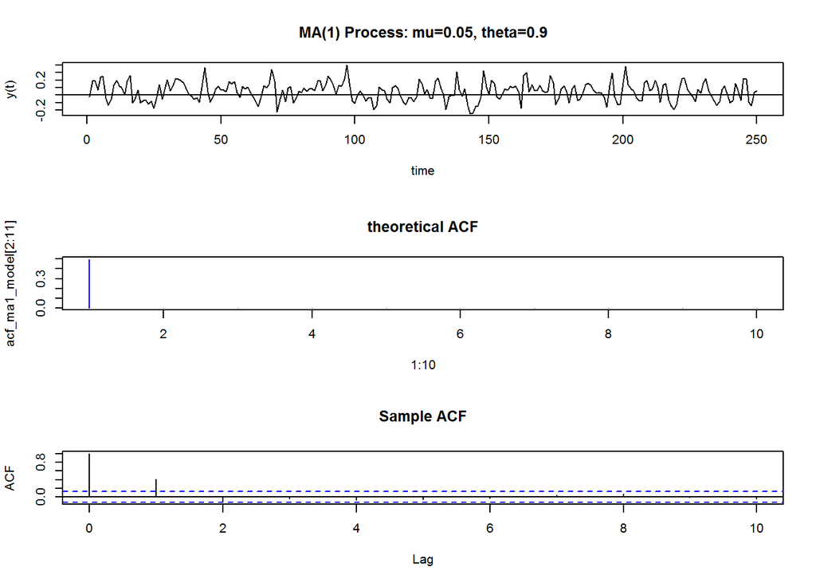

```r
set.seed(123);
# Simulate 250 observations from the described MA(1) model
ma1_sim <- arima.sim(model=list(ma=0.9), n=250, mean=0, sd=0.1) + 0.05;
# Generate the theoretical ACF with upto lag 10
acf_ma1_model <- ARMAacf(ma=0.9, lag.max=10)
# Split plotting window in three rows
par(mfrow=c(3,1))
# First plot: The simulated observations
plot(ma1_sim, type="l",main="MA(1) Process: mu=0.05, theta=0.9",xlab="time",ylab="y(t)")
abline(h=0)
# Second plot: Theoretical ACF
plot(1:10, acf_ma1_model[2:11], type="h", col="blue", main="theoretical ACF")
# Third plot: Sample ACF
tmp = acf(ma1_sim, lag.max=10, main="Sample ACF")
```

```r
# Reset graphical window to only one graph
par(mfrow=c(1,1))
```

# task 5 An AR(1) model

- Assign to ar1_sim 250 observations simulated from the described AR(1) model.
- Assign to acf_ar1_model the theoretical autocorrelations up to lag 10.
- Create the three plot functions from the previous exercise but now for the AR(1) model instead of the MA(1) model. Have a look at the code of the previous exercise if you are unsure.

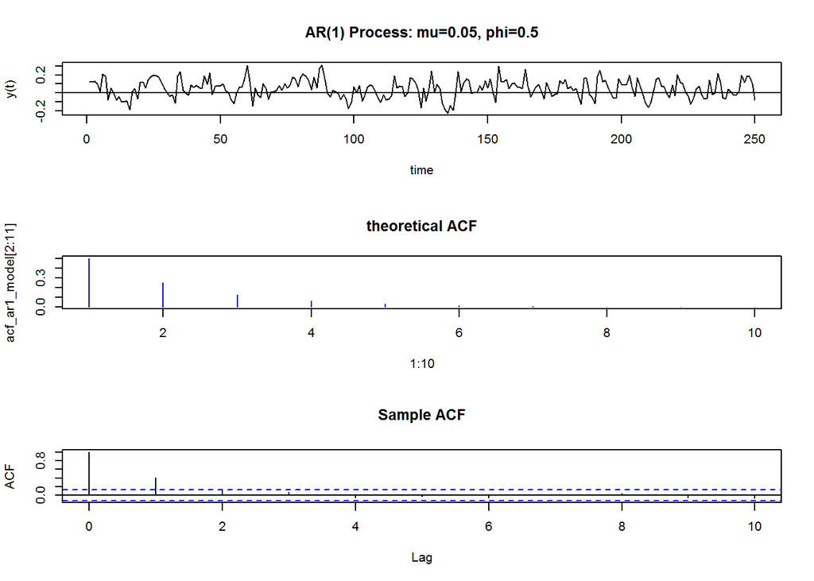

```r
set.seed(123);
# Simulate 250 observations from the described AR(1) model
ar1_sim <- arima.sim(model=list(ar=0.5), n=250, mean=0, sd=0.1) + 0.05;
# Generate the theoretical ACF with ten lags
acf_ar1_model <- ARMAacf(ar=0.5, lag.max=10)
# Split plotting window in three rows
par(mfrow=c(3,1))
# Generate the same three graphs as in the previous exercise
par(mfrow=c(3,1))
# First plot: The simulated observations
plot(ar1_sim, type="l", main="AR(1) Process: mu=0.05, phi=0.5",xlab="time",ylab="y(t)")
abline(h=0)
# Second plot: Theoretical AFC
plot(1:10, acf_ar1_model[2:11], type="h", col="blue", main="theoretical ACF")
# Third plot: Sample AFC
tmp <- acf(ar1_sim, lag.max=10, main="Sample ACF")
```

```r
# Reset plotting window to default
par(mfrow=c(1,1));
```

# Matrix Algebra Quiz

```r
A <- matrix(c(1,4,7,2,4,8,6,1,3), byrow = T, nrow = 3)
B <- matrix(c(4,4,0,5,9,1,2,2,5), byrow = T, nrow = 3)
x <- matrix(c(1,2,3), byrow = F, nrow = 3)
y <- matrix(c(5,2,7), byrow = F, nrow = 3)
```

# Question 1

```r
t(A)
```

```
##      [,1] [,2] [,3]
## [1,]    1    2    6
## [2,]    4    4    1
## [3,]    7    8    3
```

# Question 2

```r
t(B)
```

```
##      [,1] [,2] [,3]
## [1,]    4    5    2
## [2,]    4    9    2
## [3,]    0    1    5
```

# Question 3

```r
t(x)
```

```
##      [,1] [,2] [,3]
## [1,]    1    2    3
```

# Question 4

```r
t(y)
```

```
##      [,1] [,2] [,3]
## [1,]    5    2    7
```

# Question 5

```r
A+B
```

```
##      [,1] [,2] [,3]
## [1,]    5    8    7
## [2,]    7   13    9
## [3,]    8    3    8
```

# Question 6

```r
A-B
```

```
##      [,1] [,2] [,3]
## [1,]   -3    0    7
## [2,]   -3   -5    7
## [3,]    4   -1   -2
```

# Question 7

```r
2*A
```

```
##      [,1] [,2] [,3]
## [1,]    2    8   14
## [2,]    4    8   16
## [3,]   12    2    6
```

# Question 8

```r
A %*% x
```

```
##      [,1]
## [1,]   30
## [2,]   34
## [3,]   17
```

# Question 9

```r
t(y) %*% A %*% x
```

```
##      [,1]
## [1,]  337
```

# Question 10

```r
M <- matrix(c(1,1,2,4),byrow = T, nrow = 2)
b <- matrix(c(1,2),byrow = T, nrow = 2)
solve(M)%*%b
```

```
##      [,1]
## [1,]    1
## [2,]    0
```

# Question 11

```r
x <- c(1/3,1/3,1/3)
mu <- c(0.01,0.04,0.02)
Sigma <- matrix(c(.1,.3,.1,.3,.15,-.2,.1,-.2,.08), nrow = 3)
t(mu)%*%x
```

```
##            [,1]
## [1,] 0.02333333
```

# Question 12

```r
t(x)%*%Sigma%*%x
```

```
##            [,1]
## [1,] 0.08111111
```